# Practicum

Kanishka Parganiha

10/13/2020

**Part 3**:

**UML Model**

https://lucid.app/invitations/accept/68c20656-cdd1-4e71-a89a-7375b5ff9604

**ASSUMPTIONS** :

The following are the various assumptions made for each table in the database: • testingcandidate: A person who visited testing center is termed as testing candidate. He is given CandidateId key as primary key for his identification

• covidtest: Each testedcandidate is given OrderId which uniquely identifies his test result of Covid Test and this key acts as primary key for the covidtest tables.

• Testingcenter: The person where he/she gets his covid test done is the testing center. The CenterId uniquely identifies the center.

• Zipcode: Table which contain the location of the State, City and Street Name

• Selfreported: This table contains the list of individuals who have not taken Covid test but shows the symptoms of covid. They self report themselves to the Authorities.

• Taskforce: Regulatory Body which does the task of contact tracing by assigning unique ReportingId number to every individuals who has done Covid Test or is suspected or has Travel History.

• Active: table which contains the list of individuals who are Covid-Positive

• Contactownership: Table created to map n:m multiplicity between contactgroupidentification and active table

• Contactgroupidentification: List of people who recently came in contact with Covid tested person

• Healthcareadmin: Health care worker who work along with the task force to monitor the infected patient and verifies the individual reports from them

**Part 4**

**Logical Model**

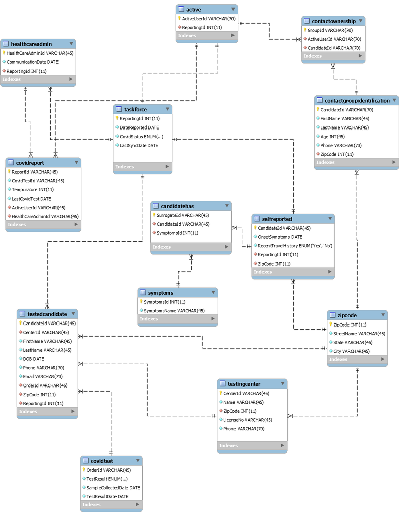

ERD Diagram Design in MySql WorkBench

• Key Icon: Primary Key • Light Red: Foreign Key

**Relational Schema**

```r
library(DBI)
library(RMySQL)
mydrv <- dbDriver("MySQL")
conn <- dbConnect(mydrv, dbname="contacttracing",host="127.0.0.1",port=3306, user="root",password="Tenda@220")
```

• testingcenter

```r
dbFetch(dbSendQuery(conn, 'desc testingcenter;'))
```

| Field | Type | Null | Key | Default | Extra |
| --- | --- | --- | --- | --- | --- |
| CenterId | varchar(45) | NO | PRI | NA |  |
| Name | varchar(45) | NO |  | NA |  |
| ZipCode | int(11) | NO | MUL | NA |  |
| LicenseNo | varchar(45) | NO |  | NA |  |
| Phone | varchar(70) | NO |  | NA |  |

• covidtest

```r
dbFetch(dbSendQuery(conn, 'desc covidtest;'))
```

| Field | Type | Null | Key | Default | Extra |
| --- | --- | --- | --- | --- | --- |
| OrderId | varchar(45) | NO | PRI | NA |  |
| TestResult | enum('Positive','Negative') | NO |  | NA |  |
| SampleCollectedDate | date | NO |  | NA |  |
| TestResultDate | date | NO |  | NA |  |

• testedcandidate

```r
dbFetch(dbSendQuery(conn, 'desc testedcandidate;'))
```

| Field | Type | Null | Key | Default | Extra |
| --- | --- | --- | --- | --- | --- |
| CandidateId | varchar(45) | NO | PRI | NA |  |
| CenterId | varchar(45) | NO | MUL | NA |  |
| FirstName | varchar(45) | NO |  | NA |  |
| LastName | varchar(45) | NO |  | NA |  |
| DOB | date | NO |  | NA |  |
| Phone | varchar(70) | NO |  | NA |  |
| Email | varchar(70) | NO |  | NA |  |
| OrderId | varchar(45) | NO | MUL | NA |  |
| ZipCode | int(11) | NO | MUL | NA |  |
| ReportingId | int(11) | NO | MUL | NA |  |

• zipcode

```r
dbFetch(dbSendQuery(conn, 'desc zipcode;'))
```

| Field | Type | Null | Key | Default | Extra |
| --- | --- | --- | --- | --- | --- |
| ZipCode | int(11) | NO | PRI | NA |  |
| StreetName | varchar(45) | NO |  | NA |  |
| State | varchar(45) | NO |  | NA |  |
| City | varchar(45) | NO |  | NA |  |

• selfreported

```r
dbFetch(dbSendQuery(conn, 'desc selfreported;'))
```

| Field | Type | Null | Key | Default | Extra |
| --- | --- | --- | --- | --- | --- |
| CandidateId | varchar(45) | NO | PRI | NA |  |
| OnsetSymptoms | date | NO |  | NA |  |
| RecentTravelHistory | enum('Yes','No') | NO |  | NA |  |
| ReportingId | int(11) | NO | MUL | NA |  |
| ZipCode | int(11) | NO | MUL | NA |  |

• symptoms

```r
dbFetch(dbSendQuery(conn, 'desc symptoms;'))
```

| Field | Type | Null | Key | Default | Extra |
| --- | --- | --- | --- | --- | --- |
| SymptomsId | int(11) | NO | PRI | NA |  |
| SymptomsName | varchar(45) | NO |  | NA |  |

• taskforce

```r
dbFetch(dbSendQuery(conn, 'desc taskforce;'))
```

| Field | Type | Null | Key | Default | Extra |
| --- | --- | --- | --- | --- | --- |
| ReportingId | int(11) | NO | PRI | NA |  |
| DateReported | date | NO |  | NA |  |
| CovidStatus | enum('Positive','Suspected','Negative') | NO |  | NA |  |
| LastSyncDate | date | NO |  | NA |  |

• active

```r
dbFetch(dbSendQuery(conn, 'desc active;'))
```

| Field | Type | Null | Key | Default | Extra |
| --- | --- | --- | --- | --- | --- |
| ActiveUserId | varchar(70) | NO | PRI | NA |  |
| ReportingId | int(11) | NO | MUL | NA |  |

• healthcareadmin

```r
dbFetch(dbSendQuery(conn, 'desc healthcareadmin;'))
```

| Field | Type | Null | Key | Default | Extra |
| --- | --- | --- | --- | --- | --- |
| HealthCareAdminId | varchar(45) | NO | PRI | NA |  |
| CommunicationDate | date | NO |  | NA |  |
| ReportingId | int(11) | NO | MUL | NA |  |

• covidreport

```r
dbFetch(dbSendQuery(conn, 'desc covidreport;'))
```

| Field | Type | Null | Key | Default | Extra |
| --- | --- | --- | --- | --- | --- |
| ReportId | varchar(45) | NO | PRI | NA |  |
| CovidTestId | varchar(45) | NO |  | NA |  |
| Tempurature | int(11) | NO |  | NA |  |
| LastCovidTest | date | NO |  | NA |  |
| ActiveUserId | varchar(45) | NO | MUL | NA |  |
| HealthCareAdminId | varchar(45) | NO | MUL | NA |  |

• contactownership

```r
dbFetch(dbSendQuery(conn, 'desc contactownership;'))
```

| Field | Type | Null | Key | Default | Extra |
| --- | --- | --- | --- | --- | --- |
| GroupId | varchar(70) | NO | PRI | NA |  |
| ActiveUserId | varchar(70) | NO | MUL | NA |  |
| CandidateId | varchar(70) | NO | MUL | NA |  |

• contactgroupidentification

```r
dbFetch(dbSendQuery(conn, 'desc contactgroupidentification;'))
```

| Field | Type | Null | Key | Default | Extra |
| --- | --- | --- | --- | --- | --- |
| CandidateId | varchar(70) | NO | PRI | NA |  |
| FirstName | varchar(45) | NO |  | NA |  |
| LastName | varchar(45) | NO |  | NA |  |
| Age | int(45) | NO |  | NA |  |
| Phone | varchar(70) | NO |  | NA |  |
| ZipCode | int(11) | NO | MUL | NA |  |

**NORMALIZATION**

1. testedcandidate The Functional Dependencies are, candidateId=> FirstName candidateId => Lastname candidateId => Phone candidateId => Email candidateId => DOB candidateId => OrderId candidateId => ReportingId Thus candidateId is the only candidate keys. This relation is in BCNF as the candidate key is the only determinants of every FD. There is no partial dependency as well. There are no transitive dependencies. And there are no multivalued attributes.
2. zipcode The Functional Dependencies are, Zipcode=> Streetname Zipcode => State Zipcode => City Thus Zipcode is the only candidate keys. This relation is in BCNF as the candidate key is the only determinants of every FD. There is no partial dependency as well. There are no transitive dependencies. And there are no multivalued attributes.
3. Normalized N:M association multiplicity between active and contactgroupidentification to 3NF form with GroupId key as surrogate Key

**Part 5**

[figure not shown]

Querying in MySql WorkBench

[figure not shown]

Forward Engineering in MySql WorkBench

– MySQL Workbench Forward Engineering

```
 CREATE SCHEMA IF NOT EXISTS `contacttracing` DEFAULT CHARACTER SET utf8 ;
 USE `contacttracing` ;
```

[output not shown]

| – | Table `contacttracing`.`active` |
| --- | --- |
|  | CREATE TABLE IF NOT EXISTS `contacttracing`.`active` ( |
|  | `ActiveUserId` VARCHAR(70) NOT NULL, |
|  | `ReportingId` INT(11) NOT NULL, |
|  | PRIMARY KEY (`ActiveUserId`), |
|  | INDEX `fk_Active_TaskForce1_idx` (`ReportingId` ASC) VISIBLE, |
|  | CONSTRAINT `fk_Active_TaskForce1` |
|  | FOREIGN KEY (`ReportingId`) |
|  | REFERENCES `contacttracing`.`taskforce` (`ReportingId`)) |
|  | ENGINE = InnoDB |
|  | DEFAULT CHARACTER SET = utf8; |

[output not shown]

| – | Table `contacttracing`.`selfreported` |
| --- | --- |
|  | CREATE TABLE IF NOT EXISTS `contacttracing`.`selfreported` ( |
|  | `CandidateId` VARCHAR(45) NOT NULL, |
|  | `OnsetSymptoms` DATE NOT NULL, |
|  | `RecentTravelHistory` ENUM(‘Yes’, ‘No’) NOT NULL, |
|  | `ReportingId` INT(11) NOT NULL, |
|  | `ZipCode` INT(11) NOT NULL, |
|  | PRIMARY KEY (`CandidateId`), |
|  | INDEX `fk_SelfReported_Task Force1_idx` (`ReportingId` ASC) VISIBLE, |
|  | INDEX `fk_SelfReported_ZipCode1_idx` (`ZipCode` ASC) VISIBLE, |
|  | CONSTRAINT `fk_SelfReported_Task Force1` |
|  | FOREIGN KEY (`ReportingId`) |
|  | REFERENCES `contacttracing`.`taskforce` (`ReportingId`), |
|  | CONSTRAINT `fk_SelfReported_ZipCode1` |
|  | FOREIGN KEY (`ZipCode`) |
|  | REFERENCES `contacttracing`.`zipcode` (`ZipCode`)) |
|  | ENGINE = InnoDB |
|  | DEFAULT CHARACTER SET = utf8; |

| – | Table `contacttracing`.`symptoms` |
| --- | --- |
|  | CREATE TABLE IF NOT EXISTS `contacttracing`.`symptoms` ( `SymptomsId` INT(11) NOT NULL, `SymptomsName` VARCHAR(45) NOT NULL, PRIMARY KEY (`SymptomsId`)) ENGINE = InnoDB DEFAULT CHARACTER SET = utf8; |

| – | Table `contacttracing`.`candidatehas` |
| --- | --- |
|  | CREATE TABLE IF NOT EXISTS `contacttracing`.`candidatehas` ( |
|  | `SurrogateId` VARCHAR(45) NOT NULL, |
|  | `CandidateId` VARCHAR(45) NOT NULL, |
|  | `SymptomsId` INT(11) NOT NULL, |
|  | PRIMARY KEY (`SurrogateId`), |
|  | INDEX `fk_candidatehas_selfreported1_idx` (`CandidateId` ASC) VISIBLE, |
|  | INDEX `fk_candidatehas_symptoms_copy1_copy11` (`SymptomsId` ASC) VISIBLE, |
|  | CONSTRAINT `fk_candidatehas_selfreported1` |
|  | FOREIGN KEY (`CandidateId`) |
|  | REFERENCES `contacttracing`.`selfreported` (`CandidateId`), |
|  | CONSTRAINT `fk_candidatehas_symptoms_copy1_copy11` |
|  | FOREIGN KEY (`SymptomsId`) |
|  | REFERENCES `contacttracing`.`symptoms` (`SymptomsId`)) |
|  | ENGINE = InnoDB |
|  | DEFAULT CHARACTER SET = utf8; |

[output not shown]

| – | Table `contacttracing`.`contactownership` |
| --- | --- |
|  | CREATE TABLE IF NOT EXISTS `contacttracing`.`contactownership` ( |
|  | `GroupId` VARCHAR(70) NOT NULL, |
|  | `ActiveUserId` VARCHAR(70) NOT NULL, |
|  | `CandidateId` VARCHAR(70) NOT NULL, |
|  | PRIMARY KEY (`GroupId`), |
|  | INDEX `fk_ContactOwnership_ContactGroupIdentification1_idx` (`CandidateId` ASC) VISIBLE, |
|  | INDEX `fk_contactownership_active1_idx` (`ActiveUserId` ASC) VISIBLE, |
|  | CONSTRAINT `fk_ContactOwnership_ContactGroupIdentification1` |
|  | FOREIGN KEY (`CandidateId`) |
|  | REFERENCES `contacttracing`.`contactgroupidentification` (`CandidateId`), |
|  | CONSTRAINT `fk_contactownership_active1` |
|  | FOREIGN KEY (`ActiveUserId`) |
|  | REFERENCES `contacttracing`.`active` (`ActiveUserId`)) |
|  | ENGINE = InnoDB |
|  | DEFAULT CHARACTER SET = utf8; |

[output not shown]

| – | Table `contacttracing`.`covidreport` |
| --- | --- |
|  | CREATE TABLE IF NOT EXISTS `contacttracing`.`covidreport` ( |
|  | `ReportId` VARCHAR(45) NOT NULL, |
|  | `CovidTestId` VARCHAR(45) NOT NULL, |
|  | `Tempurature` INT(11) NOT NULL, |
|  | `LastCovidTest` DATE NOT NULL, |
|  | `ActiveUserId` VARCHAR(45) NOT NULL, |
|  | `HealthCareAdminId` VARCHAR(45) NOT NULL, |
|  | PRIMARY KEY (`ReportId`), |
|  | INDEX `fk_CovidReport_Active1_idx` (`ActiveUserId` ASC) VISIBLE, |
|  | INDEX `fk_CovidReport_HealthCareAdmin1_idx` (`HealthCareAdminId` ASC) VISIBLE, |
|  | CONSTRAINT `fk_CovidReport_Active1` |
|  | FOREIGN KEY (`ActiveUserId`) |
|  | REFERENCES `contacttracing`.`active` (`ActiveUserId`), |
|  | CONSTRAINT `fk_CovidReport_HealthCareAdmin1` |
|  | FOREIGN KEY (`HealthCareAdminId`) |
|  | REFERENCES `contacttracing`.`healthcareadmin` (`HealthCareAdminId`)) |
|  | ENGINE = InnoDB |
|  | DEFAULT CHARACTER SET = utf8; |

[output not shown]

| – | Table `contacttracing`.`testingcenter` |
| --- | --- |
|  | CREATE TABLE IF NOT EXISTS `contacttracing`.`testingcenter` ( |
|  | `CenterId` VARCHAR(45) NOT NULL, |
|  | `Name` VARCHAR(45) NOT NULL, |
|  | `ZipCode` INT(11) NOT NULL, |
|  | `LicenseNo` VARCHAR(45) NOT NULL, |
|  | `Phone` VARCHAR(70) NOT NULL, |
|  | PRIMARY KEY (`CenterId`), |
|  | INDEX `fk_TestingCenter_ZipCode1_idx` (`ZipCode` ASC) VISIBLE, |
|  | CONSTRAINT `fk_TestingCenter_ZipCode10` |
|  | FOREIGN KEY (`ZipCode`) |
|  | REFERENCES `contacttracing`.`zipcode` (`ZipCode`)) |
|  | ENGINE = InnoDB |
|  | DEFAULT CHARACTER SET = utf8; |

| – | Table `contacttracing`.`testedcandidate` |
| --- | --- |

```
 CREATE TABLE IF NOT EXISTS `contacttracing`.`testedcandidate` (
   `CandidateId` VARCHAR(45) NOT NULL,
   `CenterId` VARCHAR(45) NOT NULL,
   `FirstName` VARCHAR(45) NOT NULL,
   `LastName` VARCHAR(45) NOT NULL,
   `DOB` DATE NOT NULL,
   `Phone` VARCHAR(70) NOT NULL,
   `Email` VARCHAR(70) NOT NULL,
   `OrderId` VARCHAR(45) NOT NULL,
   `ZipCode` INT(11) NOT NULL,
   `ReportingId` INT(11) NOT NULL,
   PRIMARY KEY (`CandidateId`),
   INDEX `OrderId_idx` (`OrderId` ASC) VISIBLE,
   INDEX `fk_TestedCandidate_Task Force1_idx` (`ReportingId` ASC) VISIBLE,
   INDEX `fk_TestedCandidate_ZipCode1_idx` (`ZipCode` ASC) VISIBLE,
   INDEX `fk_testedcandidate_testingcenter1_idx` (`CenterId` ASC) VISIBLE,
   CONSTRAINT `OrderId0`
     FOREIGN KEY (`OrderId`)
     REFERENCES `contacttracing`.`covidtest` (`OrderId`),
   CONSTRAINT `fk_TestedCandidate_Task Force1`
     FOREIGN KEY (`ReportingId`)
     REFERENCES `contacttracing`.`taskforce` (`ReportingId`),
   CONSTRAINT `fk_TestedCandidate_ZipCode1`
     FOREIGN KEY (`ZipCode`)
     REFERENCES `contacttracing`.`zipcode` (`ZipCode`),
   CONSTRAINT `fk_testedcandidate_testingcenter1`
     FOREIGN KEY (`CenterId`)
     REFERENCES `contacttracing`.`testingcenter` (`CenterId`))
 ENGINE = InnoDB
 DEFAULT CHARACTER SET = utf8;
```

SET SQL_MODE=@OLD_SQL_MODE; SET FOREIGN_KEY_CHECKS=@OLD_FOREIGN_KEY_CHECKS; SET UNIQUE_CHECKS=@OLD_UNIQUE_CHECKS;

**Part 6** Insertion Queries

INSERT INTO zipcode (ZipCode,StreetName,State,City) VALUES (“10784”,“Opal Village”, “California”,“Los Angeles”), (“50835”,“Cartwright Meadow”,“Minnesota”,“Saint Paul”), (“19379”,“Pagac Ramp”,“Tennessee”,“Nashville”), (“42252”,“Rogers Extension”,“Georgia”,“Atlanta”), (“84000”,“Marielle Coves”,“California”,“Los Angeles”), (“06774”,“Crooks Roads”,“California”,“Los Angeles”), (“12422”,“Anibal Stream”,“New York”,“Buffalo”), (“53856”,“Daphne Plains”,“New York”,“New York City”), (“10906”,“Wyman Inlet”,“Missouri”,“Kansas City”), (“02066”,“Camron Flat”,“Missouri”,“Kansas City”)

INSERT INTO testingcenter (CenterId,Name,ZipCode,LicenseNo,Phone) VALUES (“GGIY930”,“Gravida”,“50835”,“CCQ63YSI9YM”,“1-257-419-2125”), (“CEBY227”,“Art Avenue”,“10906”,“IIE27FLI1SU”,“1-694-581-9531”), (“TXEY205”,“Dolor”,“50835”,“IIZ44UHK7MZ”,“1-572-524-4960”), (“EYXM942”,“Elite”,“12422”,“YXM70XGK6FD”,“1-613-416-2970”) ,(“ZXME144”,“996 Hawk”,“53856”,“TSZ13NHE3OV”,“1-455-963-8898”) ,(“ANWV749”,“Auctor”,“06774”,“FIU46JOV5DK”,“1-561-744-6198”) ,(“COOK457”,“Porttitor”,“19379”,“CPC43TNY2BP”,“1-517-122-5863”);

INSERT INTO taskforce (ReportingId,DateReported,CovidStatus,LateSyncDate) VALUES (“251697”,“2020-08-01”,“Positive”,“2020-09-07”), (“978362”,“2020-08-07”,“Negative”,“2020-09-16”) ,(“880509”,“2020-08-14”,“Negative”,“2020-09-24”) ,(“989349”,“2020-08-04”," Positive “,”2020-09-12 “), (”985882“,”2020-08-05“,” Positive “,”2020-10-01 “) ,(”597538“,”2020-08-25“,”Negative“,”2020-09-20 “) ,(”381416“,”2020-08-19“,”Negative“,”2020-10-01 ");

INSERT INTO covidtest (OrderId,TestResult,SampleCollectedDate,TestResultDate) VALUES (“920317”,“Positive”,“2020-09-05”,“2020-09-18”) ,(“795954”,“Negative”,“2020-09-13”,“2020-09-22”) ,(“143503”,“Negative”,“2020-09-01”,“2020-09-27”), (“153649”,“Negative”,“2020-09-03”,“2020-09-24”), (“342421”,“Positive”,“2020-09-04”,“2020-10-01”) ,(“280492”,“Positive”,“2020-09-06”,“2020-09-18”) ,(“871028”,“Negative”,“2020-09-10”,“2020-09-17”);

INSERT INTO testedcandidate (CandidateId,CenterId,FirstName,LastName,DOB,Phone,Email,OrderId,ZipCode,ReportingId) VALUES (“SJG20231”,“GGIY930”,“Nissim”,“Dyer”,“1969-12-31”,“1-736-566-4425”,“eget.ipsum.Donec@mollis.org”,“920317”,“50835”,“251697”), (“RQV30513”,“GGIY930”,“Tanek”,“Jackson”,“1969-12-31”,“1-379-748-3323”,“consequat@diamDuismi.ca”,“153649”,“50835”,“978362”) ,(“UZK77843”,“COOK457”,“Howard”,“Murray”,“1969-12-31”,“1-469-932-4425”,“Donec.porttitor.tellus@risus.co.uk”,“143503”,“12422”,“880509”), (“QKN80556”,“ANWV749”,“Kennedy”,“Burks”,“1969-12-31”,“1-423-727-1379”,“nulla.Integer@non.com”,“280492”,“06774”,“989349”) ,(“EWK36743”,“ANWV749”,“Armando”,“Byrd”,“1969-12-31”,“1-433-304-0459”,“Mauris.magna.Duis@accumsan.ca”,“342421”,“10906”,“985882”) ,(“HKV04560”,“COOK457”,“Zahir”,“Carrillo”,“1969-12-31”,“1-242-445-5926”,“at@Nullamsuscipitest.edu”,“871028”,“10906”,“597538”);

INSERT INTO active(ActiveUserId,ReportingId) VALUES (“YLHR6228”, “251697”) ,(“VFDW5805”, “985882”) ,(“GSPA4057”, “880509”) ,(“DHFO0615”, “989349”) ,(“AZUV4790”, “597538”) ;

INSERT INTO contactownership(GroupId,ActiveUserId,CandidateId) VALUES (“YPRF8254”,“YLHR6228”,“GQE90JPK5FW”) ,(“QIXA9762”,“YLHR6228”,“CEZ69SVV9UP”), (“ZAUX3675”,“AZUV4790”,“QTN93SQL2NT”) ,(“YRFX0967”,“GSPA4057”,“BOX43QJO1RC”) ,(“FVDY0232”,“GSPA4057”,“UHQ19LMB1CW”) ,(“UIQK1684”,“DHFO0615”,“HLT72MYQ0AD”) ,(“EALB5226”,“DHFO0615”,“SEH67PLL8CQ”);

INSERT INTO contactgroupidentifation (CandidateId,FirstName,LastName,Age,Phone,ZipCode) VALUES (“GQE90JPK5FW”,“Paki”,“Mcleod”,63,“1-280-718-6158”,“10784”), (“CEZ69SVV9UP”,“Stephen”,“Donaldson”,27,“1-391-668-5319”,“10784”), (“QTN93SQL2NT”,“Luke”,“Acosta”,28,“1-428-924-1661”,“10784”) ,(“BOX43QJO1RC”,“Mark”,“Daniel”,52,“1-899-469-8162”,“53856”),(“LZN80WNE1AC”,“Raphael”,“Solis”,48,“1-217-717-5298”,“53856”), (“UHQ19LMB1CW”,“Brian”,“Wallace”,25,“1-772-853-6244”,“9140 BQ”), (“XNF54NCA9ND”,“Hunter”,“English”,67,“1-535-613-8886”,“84000”) ,(“NRK70ETP3GQ”,“Garrett”,“Dotson”,74,“1-140-606-3623”,“84000”) ,(“PWP42ZWP7HZ”,“Josiah”,“Donovan”,38,“1-833-769-1358”,“84000”) ,(“HLT72MYQ0AD”,“Reed”,“Jordan”,59,“1-551-240-8825”,“42252”), (“VUY82RPM9OQ”,“Francis”,“Preston”,59,“1-984-893-9905”,“42252”) ,(“SEH67PLL8CQ”,“Erich”,“Cline”,75,“1-240-874-0345”,“02066”), (“WWL05CBK8KK”,“Brady”,“Roach”,66,“1-199-822-7523”,“02066”) ,(“UQR13TRB0PM”,“Arden”,“Garrison”,41,“1-150-792-8389”,“02066”), (“THR30OAQ8CR”,“Jackson”,“Acosta”,37,“1-485-145-6002”,“84000”);

INSERT INTO healthcareadmin (HealthCareAdminId,CommunicationDate,ReportingId) VALUES (“SL833UT3GQ”,“2020-10-03”,“251697”) ,(“SW436HG6OL”,“2020-09-27”,“989349”) ,(“VE799NF5RI”,“2020-10-06”,“985882”) ,(“QH791SY9TR”,“2020-10-06”,“381416”) ,(“GH647AI9BB”,“2020-10-11”,“597538”);

INSERT INTO covidreport (ReportId,CovidTestId,Tempurature,LastCovidTest,ActiveUserId,HealthCareAdminId) VALUES (“KF405IX4MJ”,“SPM54UIR2GS”,116,“2020-10-28”," AZUV4790“,” SL833UT3GQ“), (”EI508SI3RW“,”XJI99EVA8IY“,91,”2020-10-07“,” DHFO0615“,” SW436HG6OL“) ,(”HO155LT3TG“,”UZQ14MPQ9CD“,116,”2020-10-23“,” GSPA4057“,” SW436HG6OL “) ,(”OC706CP9PJ“,”BBJ31TZM7TD“,94,”2020-10-01“,” VFDW5805“,” SW436HG6OL“) ,(”KL540BY8LF“,”MRL95LMA0SY“,116,”2020-10-19“,” YLHR6228“,” GH647AI9BB ");

INSERT INTO selfreported (CandidateId,OnsetSymptomsDate,RecentTravelHistory,ReportingId,ZipCode) VALUES (“HS018AS3EE”,“2020-09-09”,“Yes”,“597538”,“10784”), (“AN574IW6EQ”,“2020-09-26”,“Yes”,“985882”,“10784”) ,(“EF588GK2NQ”,“2020-09-30”,“No”,“880509”,“42252”); INSERT INTO candidatehas (SurrogateId,CandidateId,SymptomsId) VALUES (“TB540YJ0ZC”,“HS018AS3EE”,1) ,(“HU221RQ1QY”,“AN574IW6EQ”,6), (“VE308AH6ES”,“EF588GK2NQ”,5);

INSERT INTO candidatehas (SymptomsId,SymptomsName) VALUES (2,“Fever”), (5,“Sore throat”), (4,“Cough”) ,(3,“Shortness of breath”) ,(1,“Nausea”);

**Part 7**.

```r
library(DBI)
library(RMySQL)

mydrv <- dbDriver("MySQL")
conn <- dbConnect(mydrv, dbname="contacttracing",host="127.0.0.1",port=3306, user="root",password="Tenda@220")
```

**QUERIES**

1. Query to display the Name, Covid Test Result, the location of their Testing center along with the Date the Task Force Authority has their data entry by using multiple join statements.

```r
dbFetch(dbSendQuery(conn, 'select tc.FirstName,tc.LastName,ct.TestResult,zc.State,tf.DateReported from testedcandidate tc inner join covidtest ct on tc.OrderId=ct.OrderId inner join testingcenter ts on ts.CenterId=tc.CenterId inner join zipcode zc on zc.zipCode=ts.zipCode inner join taskforce tf on tf.ReportingId=tc.ReportingId ;'))
```

| FirstName | LastName | TestResult | State | DateReported |
| --- | --- | --- | --- | --- |
| Armando | Byrd | Positive | California | 2020-08-05 |
| Zahir | Carrillo | Negative | Tennessee | 2020-08-25 |
| Kennedy | Burks | Positive | California | 2020-08-04 |
| Tanek | Jackson | Negative | Minnesota | 2020-08-07 |
| Nissim | Dyer | Positive | Minnesota | 2020-08-01 |
| Howard | Murray | Negative | Tennessee | 2020-08-14 |

2. Query to display the Name and contact Details of the potential Covid infected persons who has contacted the Person whose covid Status was ‘Positive’ in the database of Task Force.

```r
dbFetch(dbSendQuery(conn, 'select FirstName,LastName,Age,Phone,ZipCode from contactgroupidentification where CandidateId  in (select co.CandidateId from contactownership co inner join active ac on ac.ActiveUserId=co.ActiveUserId inner join taskforce tf on tf.ReportingId=ac.ReportingId where tf.CovidStatus="Positive");'))
```

| FirstName | LastName | Age | Phone | ZipCode |
| --- | --- | --- | --- | --- |
| Erich | Cline | 75 | 1-240-874-0345 | 2066 |
| Stephen | Donaldson | 27 | 1-391-668-5319 | 10784 |
| Reed | Jordan | 59 | 1-551-240-8825 | 42252 |
| Paki | Mcleod | 63 | 1-280-718-6158 | 10784 |

```r
dbFetch(dbSendQuery(conn, 'select StreetName,count(*) as TestingCount from zipcode  group by State having count(*)>1;'))
```

| StreetName | TestingCount |
| --- | --- |
| Camron Flat | 2 |
| Crooks Roads | 3 |
| Anibal Stream | 2 |

```r
dbFetch(dbSendQuery(conn, 'select hc.ReportingId,cr.Tempurature,tf.CovidStatus from covidreport cr inner join healthcareadmin hc on cr.HealthCareAdminId=hc.HealthCareAdminId inner join taskforce tf on tf.ReportingId=hc.ReportingId  where cr.Tempurature >90 and tf.CovidStatus = "Positive" ;'))
```

| ReportingId | Tempurature | CovidStatus |
| --- | --- | --- |
| 989349 | 91 | Positive |
| 989349 | 116 | Positive |
| 251697 | 116 | Positive |
| 989349 | 94 | Positive |

5. Query to display risk-wise status patient according to their age and CovidStatus of their recent Contact Person carrying Covid.

```r
dbFetch(dbSendQuery(conn, 'select FirstName,LastName,Age,
                    CASE
                          WHEN Age > 50 THEN "Higher Risk"
                          WHEN Age < 50 THEN "Mild Risk"

                          END as Risk

                        from contactgroupidentification where CandidateId  in (select co.CandidateId from contactownership co inner join active ac on ac.ActiveUserId=co.ActiveUserId inner join taskforce tf on tf.ReportingId=ac.ReportingId where tf.CovidStatus="Positive");'))
```

| FirstName | LastName | Age | Risk |
| --- | --- | --- | --- |
| Stephen | Donaldson | 27 | Mild Risk |
| Paki | Mcleod | 63 | Higher Risk |
| Erich | Cline | 75 | Higher Risk |
| Reed | Jordan | 59 | Higher Risk |